# 12_linear_model3

Tobias Gerstenberg

2/8/2021

> I forget to turn the recording back on after the breakout room. Sorry about that!

## Student feedback

> sometimes you use random stats words that you haven’t explain which can make it a little difficult to follow what you’re saying. Like today, you said “gaussian nose” but we haven’t learned what that means so in order to understand what you’re saying I have to try to figure out what that means. It would be great if you could give quick 1-sentence summaries of new terms

> do you have info on how long the midterm took students to complete last year?

> just a general question - how many problem sets are there in this class? Will there be problem sets at the same time as final project assignments later in the quarter, or will problem sets phase out?

|  | Response |
| --- | --- |
| 1 | sometimes you use random stats words that you haven't explain which can make it a little difficult to follow what you're saying. Like today, you said "gaussian nose" but we haven't learned what that m… |
| 2 | do you have info on how long the midterm took students to complete last year? |
| 3 | Explanations were really good! Didn't quite understand the point of the breakout room |
| 4 | As someone who does not remember learning ANOVA previously, I really enjoyed the perspective that ANOVA tells us how much of the variance is accounted for by the model (e.g. additional predictors) and… |
| 5 | Im a little confused about where to use ANOVA and where to stick to t-tests etc |
| 6 | just a general question - how many problem sets are there in this class? Will there be problem sets at the same time as final project assignments later in the quarter, or will problem sets phase out? |
| 7 | I feel like the explanations weren't that clear on some of the concepts. I'm not sure how I would improve them but I think it might've been going back and forth between how the package does it, how to… |

## PollEverywhere results

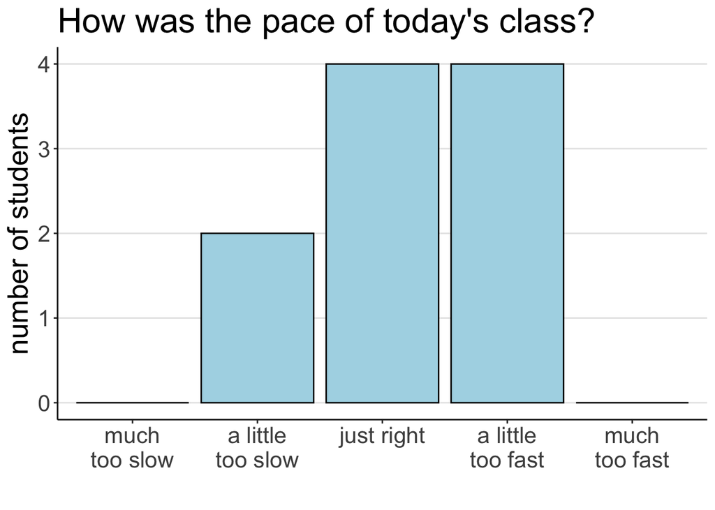

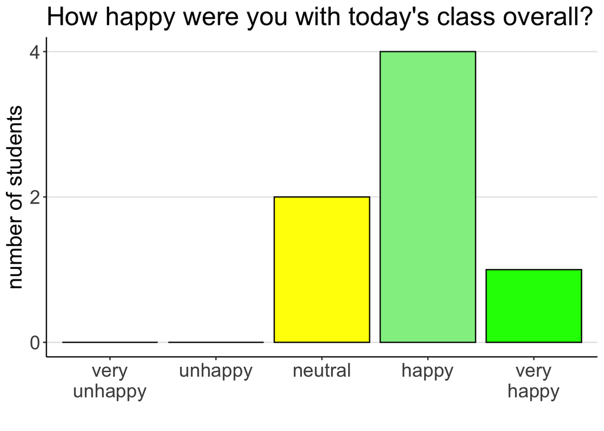

## What to do next time

- might want to spend more time next time explaining variance decomposition
- have a concrete example in which the difference in interpretation of a coefficient as a main effect vs. simple effect becomes very clear